# ETF Weekly Return

Edward J. Xu

In this project, the weekly returns for an ETF is analyzed and modelled. An ETF (Exchange Traded Fund) can be described as a structured publicly traded pool of shares. ETFs are bought and sold in the same way as ordinary shares on a stock exchange.

An ETF is a pooled investment fund similar to a unit trust or mutual fund. For investors, ETFs blend the benefits of pooled funds and shares.

The available data is found in the file and consists of 2 columns. The first column is a date column and the second column indicates the weekly returns (i.e. the ratio between the final and initial price for that week minus 1) of 1 ETF.

An important aspect of financial date is the volatility, i.e. standard error of the return. In this assignment you will explore properties of volatility and return in the given data, and a model for the time evolution of these.

# 1 Descriptive statistics and initial analysis

## 1 a)

Present the data, estimate the parameters in a normal model, and asses if the normal model is appropriate.

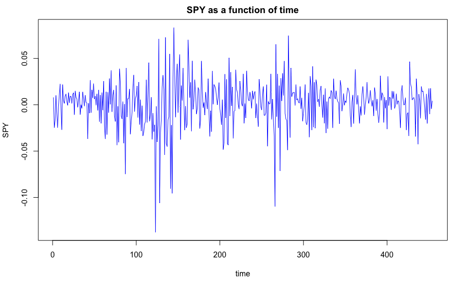

```r
dataETF <- read.csv("finance_data.csv", sep = ";")
time <- dataETF[, 1]
SPY <- dataETF[, 2]
x <- seq(1, length(time))
dataETF.f <- data.frame(x, time, SPY)
plot(dataETF.f$x, dataETF$SPY, type = 'l', col = "blue", xlab = 'time', ylab = 'SPY', main = 'SPY as a function of time')
```

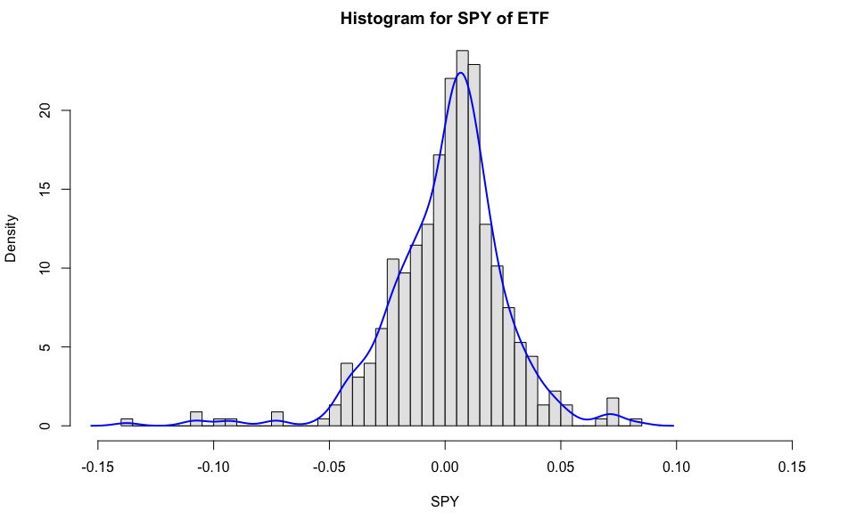

```r
hist(dataETF.f$SPY, prob = TRUE, breaks = 50, main = "Histogram for SPY of ETF", xlab = "SPY", col = "gray90", xlim = c(-0.15, 0.15))
lines(density(dataETF.f$SPY), lwd = 2, col = 4)
```

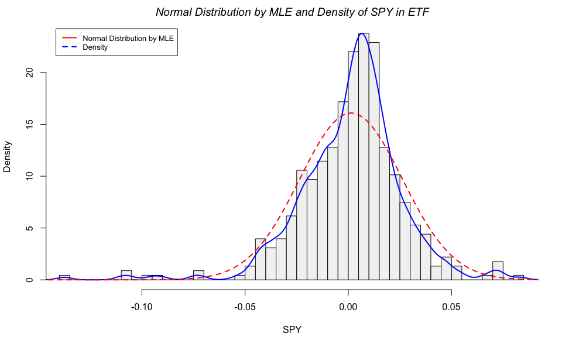

```r
# Define function that return negative log-likelihood for gamma distribution
negaLogL_normal <- function(pars, data){
    return(-sum(dnorm(x = data, mean = pars[1], sd = pars[2], log = TRUE)))
}
optDnormSPY <- function(data){
    # Optimize alpha and theta parameters in normal distribution
    dnorm.optim <- optim(c(0.1, 0.1), fn = negaLogL_normal, gr = NULL, data = data)
    # Plot optimized normal distribution density and density of SPY
    density_SPY <- density(data, adjust = 0.7)
    seqX_SPY <- seq(-0.15, 0.15, length.out = 100)
    dnorm.optim_SPY = dnorm(seqX_SPY, mean = dnorm.optim$par[1], sd = dnorm.optim$par[2])
    hist(data, breaks = 50, prob = TRUE, main = NULL, xlim = c(min(data), max(data)), xlab = "SPY", ylab = "Density", col = "gray95")
    lines(density_SPY$x, density_SPY$y, col = 'blue', lwd = 2)
    lines(seqX_SPY, dnorm.optim_SPY, col = 'red', lwd = 2, lty = 2)
    legend("topleft", inset = .02, legend = c("Normal Distribution by MLE", "Density"), col = c("red", "blue"), lty = c(1, 2), lwd = c(2, 2), cex = 0.8)
    return(dnorm.optim)
}
dnorm.optim_1 <- optDnormSPY(dataETF.f$SPY)
title(main = "Normal Distribution by MLE and Density of SPY in ETF", font.main = 3)
```

```r
logL_dnorm.optim_1 <- - negaLogL_normal(dnorm.optim_1$par, dataETF.f$SPY)
aic_dnorm.optim_1 <- - 2 * logL_dnorm.optim_1 + 2 * 2
aic_dnorm.optim_1
```

```
[1] -2065.913
```

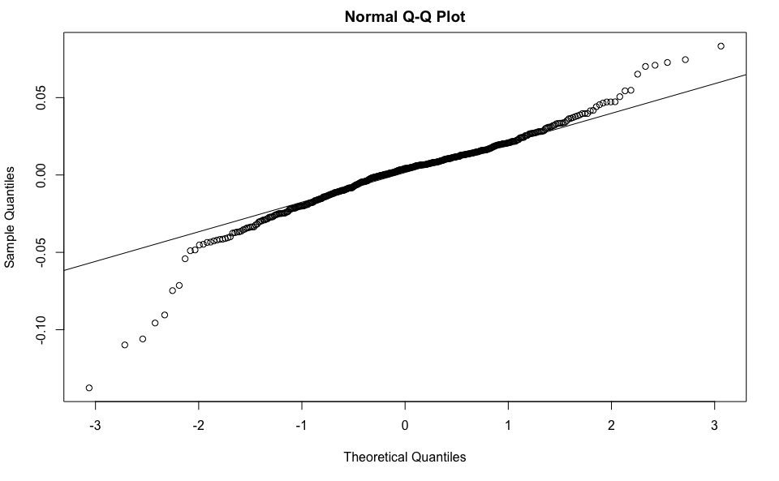

```r
qqnorm(dataETF.f$SPY)
qqline(dataETF.f$SPY)
```

## 1 b)

Hypothesize a model that could fit the data better (Hint: consider tail probabilities), and compare with the normal model estimated above

The probability that a random variable deviates by a given amount from its expectation is referred to as a tail probability.

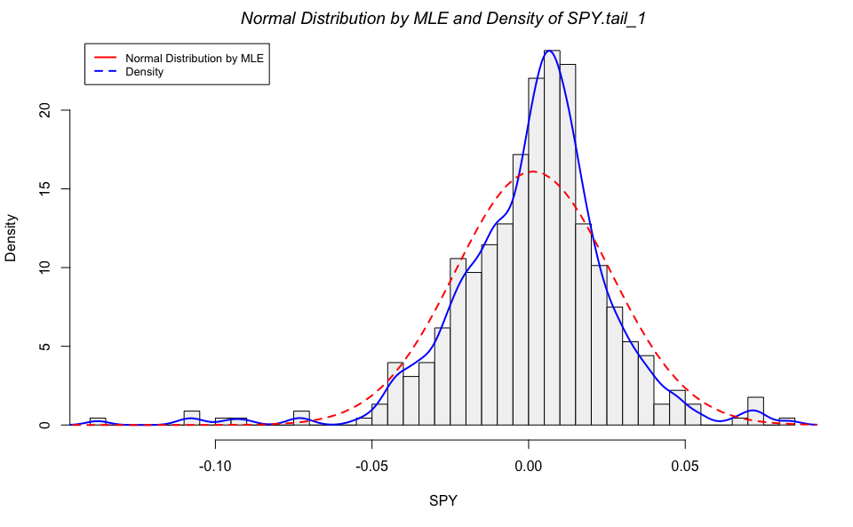

```r
tail <- 0.14
SPY.tail_1 <- dataETF.f$SPY[(dataETF.f$SPY < mean(dataETF.f$SPY) + tail) & (dataETF.f$SPY > mean(dataETF.f$SPY) - tail)]
## Plot
dnorm.optim_2 <- optDnormSPY(SPY.tail_1)
title(main = "Normal Distribution by MLE and Density of SPY.tail_1", font.main = 3)
```

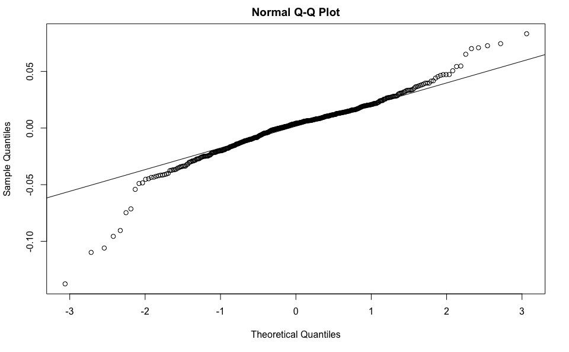

```r
qqnorm(dataETF.f$SPY)
qqline(SPY.tail_1)
```

```r
logL_dnorm.optim_2 <- - negaLogL_normal(dnorm.optim_2$par, dataETF.f$SPY)
aic_dnorm.optim_2 <- - 2 * logL_dnorm.optim_2 + 2 * 2
aic_dnorm.optim_2
```

```
[1] -2065.913
```

### 2, tail <- 0.04

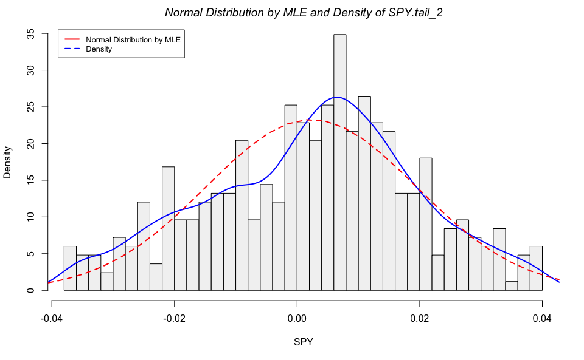

```r
tail <- 0.04
SPY.tail_2 <- dataETF.f$SPY[(dataETF.f$SPY < mean(dataETF.f$SPY) + tail) & (dataETF.f$SPY > mean(dataETF.f$SPY) - tail)]
## Plot
dnorm.optim_3 <- optDnormSPY(SPY.tail_2)
title(main = "Normal Distribution by MLE and Density of SPY.tail_2", font.main = 3)
```

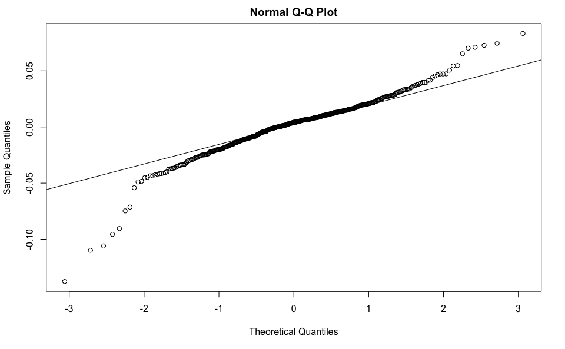

```r
qqnorm(dataETF.f$SPY)
qqline(SPY.tail_2)
```

```r
logL_dnorm.optim_3 <- - negaLogL_normal(dnorm.optim_3$par, dataETF.f$SPY)
aic_dnorm.optim_3 <- - 2 * logL_dnorm.optim_3 + 2 * 2
aic_dnorm.optim_3
```

```
[1] -1905.92
```

### tail <- 0.02

```r
tail <- 0.02
SPY.tail_3 <- dataETF.f$SPY[(dataETF.f$SPY < mean(dataETF.f$SPY) + tail) & (dataETF.f$SPY > mean(dataETF.f$SPY) - tail)]
## Plot
dnorm.optim_4 <- optDnormSPY(SPY.tail_3)
```

```
NaNs producedNaNs produced
```

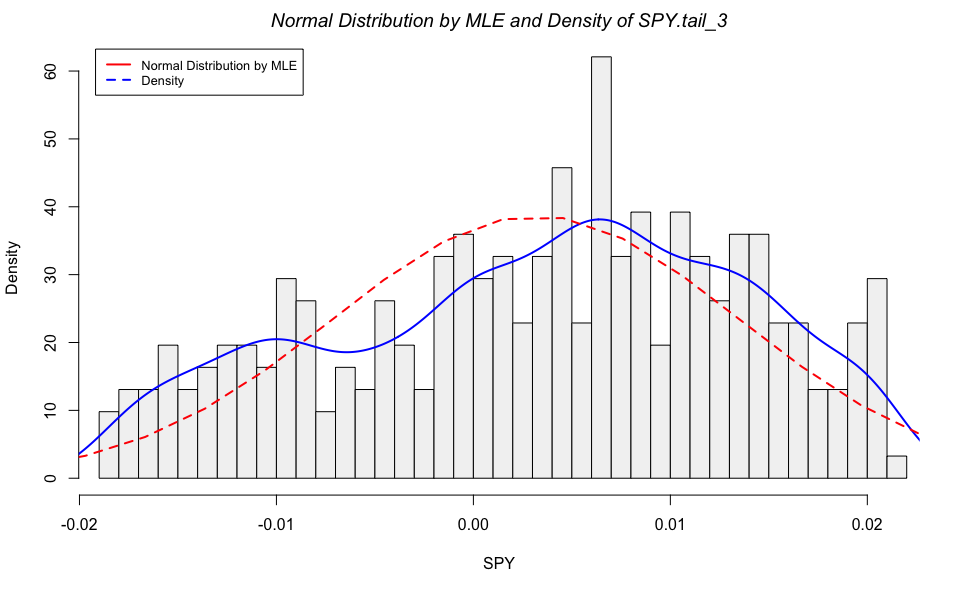

```r
title(main = "Normal Distribution by MLE and Density of SPY.tail_3", font.main = 3)
```

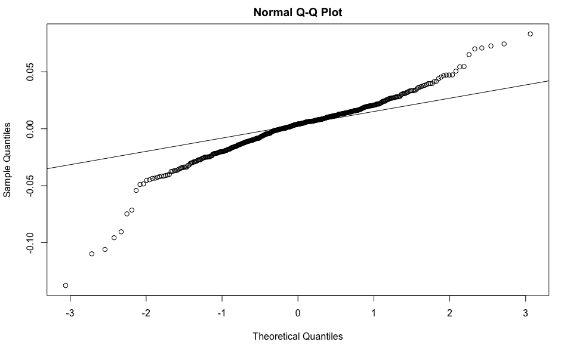

```r
qqnorm(dataETF.f$SPY)
qqline(SPY.tail_3)
```

```r
logL_dnorm.optim_4 <- - negaLogL_normal(dnorm.optim_4$par, dataETF.f$SPY)
aic_dnorm.optim_4 <- - 2 * logL_dnorm.optim_4 + 2 * 2
aic_dnorm.optim_4
```

```
[1] -684.9194
```

### tail <- 0.06

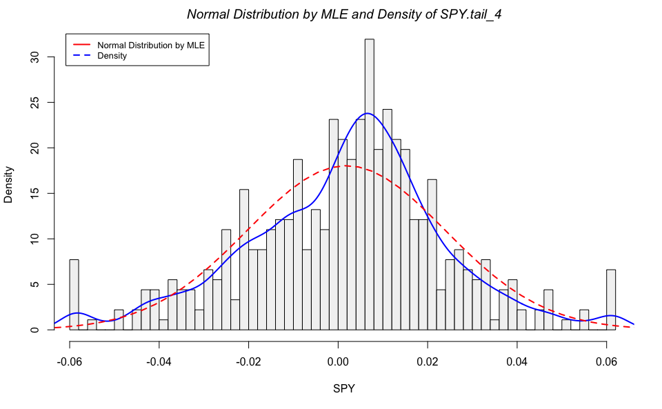

```r
tail <- 0.06
SPY.tail_4 <- dataETF.f$SPY
SPY.tail_4[SPY.tail_4 > mean(dataETF.f$SPY) + tail] <- mean(dataETF.f$SPY) + tail
SPY.tail_4[SPY.tail_4 < mean(dataETF.f$SPY) - tail] <- mean(dataETF.f$SPY) - tail
## Plot
dnorm.optim_5 <- optDnormSPY(SPY.tail_4)
title(main = "Normal Distribution by MLE and Density of SPY.tail_4", font.main = 3)
```

```r
logL_dnorm.optim_5 <- - negaLogL_normal(dnorm.optim_5$par, dataETF.f$SPY)
aic_dnorm.optim_5 <- - 2 * logL_dnorm.optim_5 + 2 * 2
aic_dnorm.optim_5
```

```
[1] -2053.248
```

### tail <- 0.03

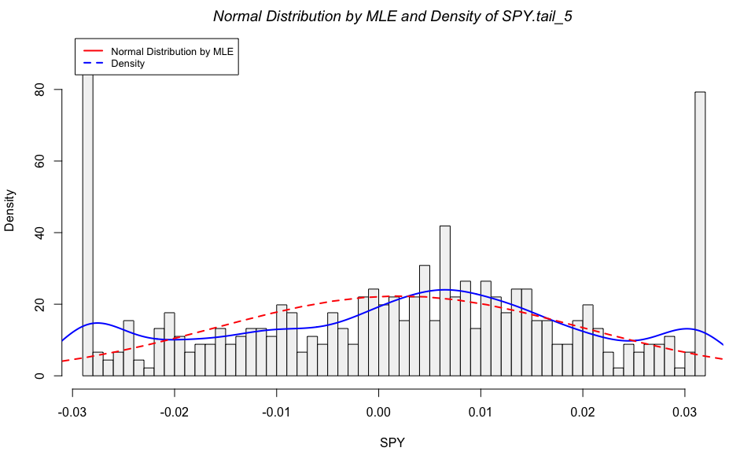

```r
tail <- 0.03
SPY.tail_5 <- dataETF.f$SPY
SPY.tail_5[SPY.tail_5 > mean(dataETF.f$SPY) + tail] <- mean(dataETF.f$SPY) + tail
SPY.tail_5[SPY.tail_5 < mean(dataETF.f$SPY) - tail] <- mean(dataETF.f$SPY) - tail
## Plot
dnorm.optim_6 <- optDnormSPY(SPY.tail_5)
title(main = "Normal Distribution by MLE and Density of SPY.tail_5", font.main = 3)
```

```r
logL_dnorm.optim_6 <- - negaLogL_normal(dnorm.optim_6$par, dataETF.f$SPY)
aic_dnorm.optim_6 <- - 2 * logL_dnorm.optim_6 + 2 * 2
aic_dnorm.optim_6
```

```
[1] -1945.169
```

## 1 c)

Present the final model (i.e. relevant keynumbers for the estimates)

# 2 Mixture model

## 2 a)

Fit normal mixture models with 2 and 3 components, argue which one is better.

```r
y <- dataETF.f$SPY
```

```r
library(mixtools)
mixtureDnorm.2 <- normalmixEM(dataETF.f$SPY, k = 2, epsilon = 1e-04)
```

```
number of iterations= 78
```

```r
kable_mixtureDnorm.2 <- data.frame(lambda = mixtureDnorm.2$lambda, mu = mixtureDnorm.2$mu, sigma.square = mixtureDnorm.2$sigma, align = "l")
kable(kable_mixtureDnorm.2)
```

[output not shown]

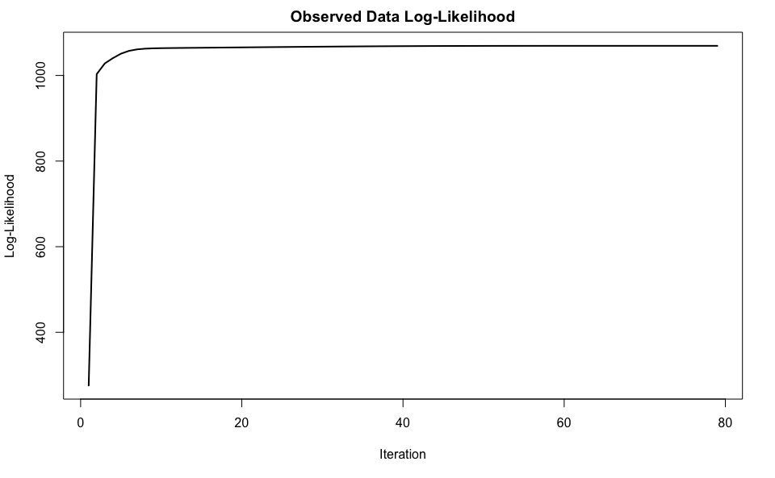

```r
plot(mixtureDnorm.2)
```

```r
seqX_SPY <- seq(-0.15, 0.15, length.out = 100)
value_mixtureDnorm.2 <- mixtureDnorm.2$lambda[1] * dnorm(seqX_SPY, mixtureDnorm.2$mu[1], mixtureDnorm.2$sigma[1]) + mixtureDnorm.2$lambda[2] * dnorm(seqX_SPY, mixtureDnorm.2$mu[2], mixtureDnorm.2$sigma[2])
hist(dataETF.f$SPY, prob = TRUE, breaks = 50, main = "Histogram for SPY of ETF", xlab = "SPY", col = "gray90", xlim = c(-0.15, 0.15))
lines(density(dataETF.f$SPY), lwd = 2, col = "blue")
```

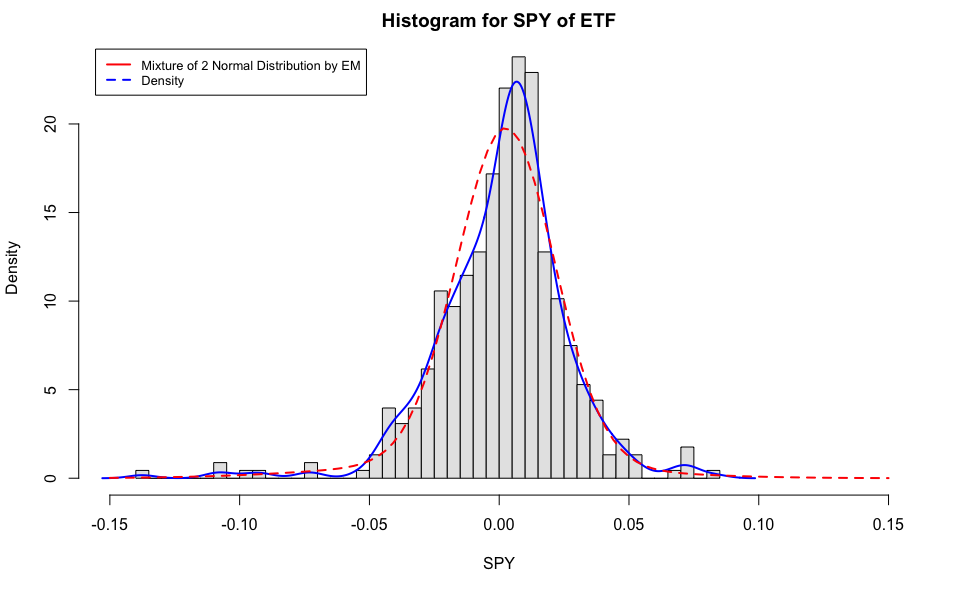

```r
lines(seqX_SPY, value_mixtureDnorm.2, lwd = 2, col = "red", lty = 2)
legend("topleft", inset = .02, legend = c("Mixture of 2 Normal Distribution by EM", "Density"), col = c("red", "blue"), lty = c(1, 2), lwd = c(2, 2), cex = 0.8)
```

```r
aic_mixtureDnorm.2 <- - 2 * tail(mixtureDnorm.2$all.loglik, n = 1) + 2 * 2
aic_mixtureDnorm.2
```

```
[1] -2134.498
```

```r
library(mixtools)
mixtureDnorm.3 <- normalmixEM(dataETF.f$SPY, k = 3, epsilon = 1e-04)
```

```
number of iterations= 63
```

```r
kable_mixtureDnorm.3 <- data.frame(lambda = mixtureDnorm.3$lambda, mu = mixtureDnorm.3$mu, sigma.square = mixtureDnorm.3$sigma)
kable(kable_mixtureDnorm.3, align = "l")
```

[output not shown]

```r
aic_mixtureDnorm.3 <- - 2 * tail(mixtureDnorm.3$all.loglik, n = 1) + 2 * 2
aic_mixtureDnorm.3
```

```
[1] -2148.856
```

```r
## EM Algorithm for mixture of two normal distribution
#  Reference: 8.5 The EM Algorithm in P272, The Element of Statistical Learning
cal_gamma <- function(pi, mu1, sigma1, mu2, sigma2, seq_y){
    gamma <- rep(0, length(seq_y))
    i <- 1
    for(y in seq_y){
        gamma[i] <- pi * dnorm(y, mean = mu2, sd = sigma2) / ((1 - pi) * dnorm(y, mean = mu1, sd = sigma1) + pi * dnorm(y, mean = mu2, sd = sigma2))
        i <- i + 1
    }
    return(gamma)
}
cal_mu1.next <- function(gamma, seq_y){
    i <- 1
    sum_1 <- 0
    sum_2 <- 0
    for(y in seq_y){
        sum.new_1 <- (1 - gamma[i]) * y
        sum_1 <- sum_1 + sum.new_1
        sum.new_2 <- (1 - gamma[i])
        sum_2 <- sum_2 + sum.new_2
        i <- i + 1
    }
    return(sum_1 / sum_2)
}
cal_mu2.next <- function(gamma, seq_y){
    i <- 1
    sum_1 <- 0
    sum_2 <- 0
    for(y in seq_y){
        sum.new_1 <- gamma[i] * y
        sum_1 <- sum_1 + sum.new_1
        sum.new_2 <- gamma[i]
        sum_2 <- sum_2 + sum.new_2
        i <- i + 1
    }
    return(sum_1 / sum_2)
}
cal_sigma1.next <- function(mu1.next, gamma, seq_y){
    i <- 1
    sum_1 <- 0
    sum_2 <- 0
    for(y in seq_y){
        sum.new_1 <- (1 - gamma[i]) * (y - mu1.next)^2
        sum_1 <- sum_1 + sum.new_1
        sum.new_2 <- (1 - gamma[i])
        sum_2 <- sum_2 + sum.new_2
        i <- i + 1
    }
    return(sum_1 / sum_2)
}
cal_sigma2.next <- function(mu2.next, gamma, seq_y){
    i <- 1
    sum_1 <- 0
    sum_2 <- 0
    for(y in seq_y){
        sum.new_1 <- gamma[i] * (y - mu2.next)^2
        sum_1 <- sum_1 + sum.new_1
        sum.new_2 <- gamma[i]
        sum_2 <- sum_2 + sum.new_2
        i <- i + 1
    }
    return(sum_1 / sum_2)
}
cal_pi.next <- function(gamma, seq_y){
    i <- 1
    sum <- 0
    for(y in seq_y){
        sum.new <- gamma[i] / length(seq_y)
        sum <- sum + sum.new
        i <- i + 1
    }
    return(sum)
}

seq_y <- y
##
pi.next <- 0.5
mu1.next <- dnorm.optim_1$par[1]
sigma1.next <- dnorm.optim_1$par[2]
mu2.next <- dnorm.optim_1$par[1] + 0.001
sigma2.next <- dnorm.optim_1$par[2] + 0.001
gamma.next <- cal_gamma(pi.next, mu1.next, sigma1.next, mu2.next, sigma2.next, seq_y)
mu1 <- mu1.next - 0.0001
j <- 1
while (abs(mu1.next - mu1) > 10^-6) {
    gamma <- gamma.next
    mu1 <- mu1.next
    sigma1 <- sigma1.next
    mu2 <- mu2.next
    sigma2 <- sigma2.next
    pi <- pi.next
    # Calculate new
    gamma.next <- cal_gamma(pi, mu1, sigma1, mu2, sigma2, seq_y)
    mu1.next <- cal_mu1.next(gamma.next, seq_y)
    sigma1.next <- cal_sigma1.next(mu1.next, gamma.next, seq_y)
    mu2.next <- cal_mu2.next(gamma.next, seq_y)
    sigma2.next <- cal_sigma2.next(mu2.next, gamma.next, seq_y)
    pi.next <- cal_pi.next(gamma.next, seq_y)
    j <- j + 1
}
```

## 2 b)

For the chosen model, report confidence interval for the parameters, and give an interpretation of these intervals.

## 2 c)

For the two component model make a profile likelihood plot of one of the variance parameters.

## 2 d)

In the previous question you should see multiple maxima, reprametrize the model such that you only see one maximum.

## 2 e)

Present the final model and discuss the interpretaion.

# 3 Hidden Markov Models

## 3 a)

Fit two and three states normal Hidden Markov Models to the data and conclude on the best choice

```r
## Hidden Markov Chain of Normal Distribution
calPn2Pw_hmmDnorm <- function(numDist, mu, sigma, gamma)
{
    t_mu <- mu
    t_sigma <- sigma
    t_gamma  <- NULL
    if (numDist > 1) {
        foo   <- log(gamma / diag(gamma))
        t_gamma<- as.vector(foo[!diag(numDist)])
    }
    list(t_mu = t_mu, t_sigma = t_sigma, t_gamma = t_gamma)
}
calPw2Pn_hmmDnorm <- function(numDist, vecPars)
{
    epar <- exp(vecPars$t_gamma)
    mu <- vecPars$t_mu
    sigma <- vecPars$t_sigma
    gamma  <- diag(numDist)
    if (numDist > 1) {
        gamma[!gamma] <- epar
        gamma         <- gamma / apply(gamma, 1, sum)
    }
    delta  <- solve(t(diag(numDist) - gamma + 1), rep(1, numDist))
    list(mu = mu, sigma = sigma, gamma = gamma, delta = delta)
}
maxLogL_hmmDnorm <- function(vecPars, x, numDist, ...)
{
#    print(vecPars)
    if(numDist == 1) return(- sum(dnorm(x, mu = vecPars[1], sigma = vecPars[2], log = TRUE)))
    n          <- length(x)
    parsNatural <- calPw2Pn_hmmDnorm(numDist, vecPars)
    allprobs   <- outer(x, c(parsNatural$mu, parsNatural$sigma), dnorm)
    allprobs   <- ifelse(!is.na(allprobs), allprobs, 1)
    scaleL     <- 0
    foo        <- parsNatural$delta
    for (i in 1: n) {
        foo    <- foo %*% parsNatural$gamma * allprobs[i,]
        sumfoo <- sum(foo)
        scaleL <- scaleL + log(sumfoo)
        foo    <- foo / sumfoo
    }
    mllk       <- -scaleL
    mllk
}
maxLE_hmmDnorm <- function(x, numDist, mu0, sigma0, gamma0,...)
{
    vecPars0 <- calPn2Pw_hmmDnorm(numDist, mu0, sigma0, gamma0)
    model <- nlm(maxLogL_hmmDnorm, unlist(vecPars0, use.names = FALSE), x = x, numDist = numDist, stepmax = 30, iterlim = 1000)
    parsNatural <- calPw2Pn_hmmDnorm(numDist, model$estimate)
    mllk <- model$minimum
    numPars <- length(vecPars0$t_mu) + length(vecPars0$t_sigma) + length(vecPars0$t_gamma)
    AIC <- 2 * (mllk + numPars)
    n <- sum(!is.na(x))
    BIC <- 2 * mllk + numPars * log(n)
    list(mu = parsNatural$mu, sigma = parsNatural$sigma, gamma = parsNatural$gamma, delta = parsNatural$delta, code = model$code, mllk = mllk, AIC = AIC, BIC = BIC)
}
```

```r
numDist <- 2
y <- dataETF.f$SPY
# mu0 <- quantile(y, c(dnorm.optim_1$par[1] * 0.9, dnorm.optim_1$par[1] * 1.1))
# sigma0 <- quantile(y, c(dnorm.optim_1$par[2] * 0.9, dnorm.optim_1$par[2] * 1.1))
mu0 <- c(dnorm.optim_1$par[1] * 0.9, dnorm.optim_1$par[1] * 1.1)
sigma0 <- c(dnorm.optim_1$par[2] * 0.9, dnorm.optim_1$par[2] * 1.1)
gamma0 <- matrix(0.05, ncol = numDist, nrow = numDist)
diag(gamma0) <- 1 - (numDist - 1) * gamma0[1,1]
## optimize
optHmmDnorm.2 <- maxLE_hmmDnorm(y, numDist, mu0, sigma0, gamma0)
```

```
Error: $ operator is invalid for atomic vectors
```

## 3 b)

For the chosen model report 95% confidence intervals for the working parameters.

## 3 c)

Report the natural parameters and interpret the result.

## 3 d)

Compare the following distributions (by plots)  
??? The long term distribution of the return.  
??? The 1-step ahead distribution given that you known the current state.

## 3 e)

Report 95% confidence intervals for some (or all) natural parameters (note that the natural paramters include the stationary distribution). Some options for finding these CI???s are  
??? Formula (3.2) in the textbook.  
??? The bootstrap method in Section 3.6.2. ??? Profile likelihood.

## 3 f)

Discuss what would be needed in order to make short term (say 1-2 weeks) predictions.